# Taller sintético: evaluar un modelo (desempeño)

# 1. Introducción

- Este taller **no entrena modelos nuevos**: toma uno y se concentra en **evaluarlo bien** — el corazón de la sesión 4.
- Usamos el **Census Income** (microdatos del censo): predecir si una persona tiene **ingreso alto** (>50K). Es un problema de **política pública** (desigualdad, focalización) y, clave para evaluar, está **desbalanceado**: la mayoría tiene ingreso bajo.
- Apoyándonos en **`caret`**, casi todo (matriz de confusión, métricas, validación cruzada) sale con **una sola función**.

# 2. Datos y un modelo simple

```r
install.packages(c("caret", "pROC", "ROSE"))
```

```r
library(caret)
library(randomForest)
censo <- read.csv("data/census_income.csv", strip.white = TRUE,
                  stringsAsFactors = TRUE, na.strings = "?")
censo[c("fnlwgt", "education", "native_country", "relationship")] <- NULL
censo <- censo[complete.cases(censo), ]
set.seed(123)
censo <- censo[sample(nrow(censo), 5000), ]
# clase de interés: ingreso "Alto" (>50K) vs "Bajo" (<=50K)
censo$income <- factor(ifelse(censo$income == ">50K", "Alto", "Bajo"), levels = c("Bajo", "Alto"))
# quitamos categorías muy raras (para que ningún nivel quede solo en una partición)
for (v in names(censo)) if (is.factor(censo[[v]])) censo <- censo[censo[[v]] %in% names(which(table(censo[[v]]) >= 40)), ]
censo <- droplevels(censo)
```

- Partimos los datos (con `createDataPartition`) y entrenamos un **random forest**:

```r
set.seed(123)
idx     <- createDataPartition(censo$income, p = 0.75, list = FALSE)
entrena <- censo[idx, ]
prueba  <- censo[-idx, ]

modelo <- randomForest(income ~ ., data = entrena)
prob   <- predict(modelo, prueba, type = "prob")[, "Alto"]    # P(ingreso alto)
pred   <- predict(modelo, prueba)                             # clase predicha
```

# 3. Matriz de confusión y métricas (una sola función)

- `confusionMatrix` arma la matriz **y** calcula todas las métricas de un solo golpe:

```r
confusionMatrix(pred, prueba$income, positive = "Alto", mode = "prec_recall")
```

```
## Confusion Matrix and Statistics
##
##           Reference
## Prediction Bajo Alto
##       Bajo  880  110
##       Alto   70  181
##
##                Accuracy : 0.855
##                  95% CI : (0.8341, 0.8741)
##     No Information Rate : 0.7655
##     P-Value [Acc > NIR] : 3.057e-15
##
##                   Kappa : 0.5758
##
##  Mcnemar's Test P-Value : 0.00365
##
##               Precision : 0.7211
##                  Recall : 0.6220
##                      F1 : 0.6679
##              Prevalence : 0.2345
##          Detection Rate : 0.1459
##    Detection Prevalence : 0.2023
##       Balanced Accuracy : 0.7742
##
##        'Positive' Class : Alto
##
```

# 4. Curva ROC y AUC

- Como tenemos una **probabilidad**, recorremos todos los umbrales. La curva ROC y el **AUC** resumen el desempeño sin fijar un umbral:

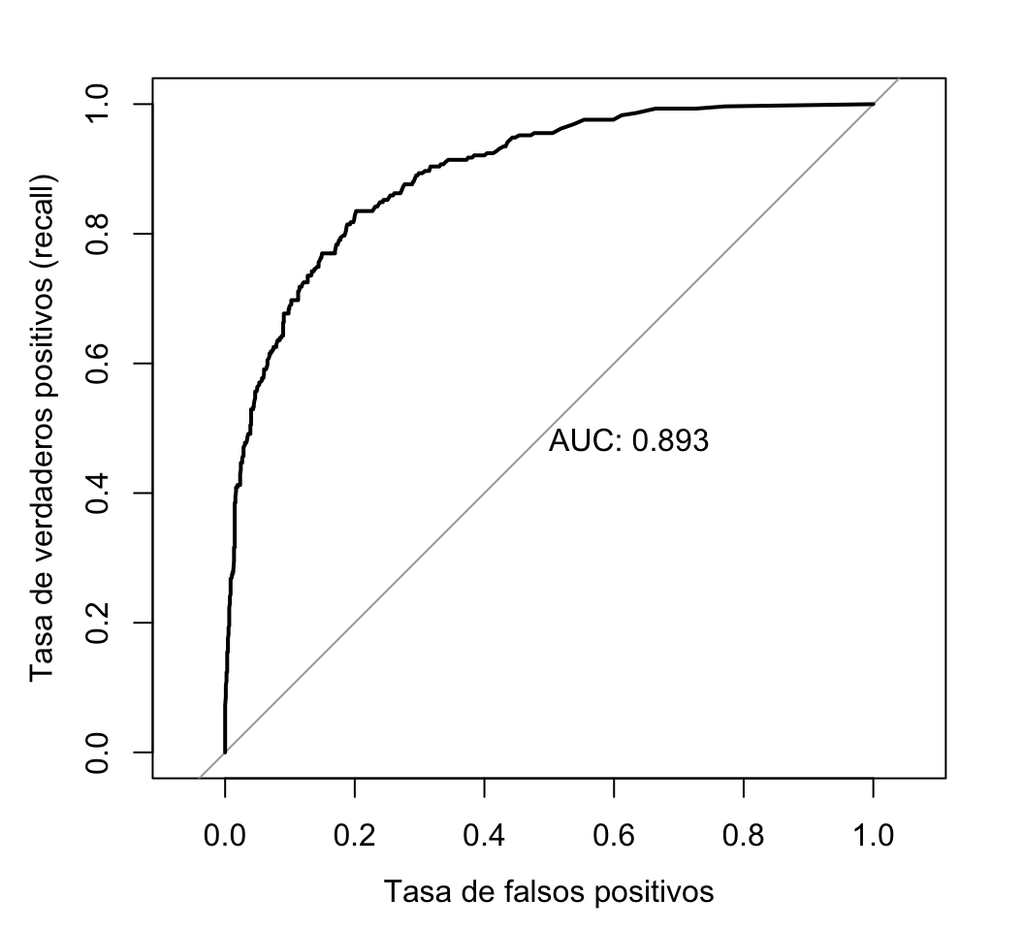

```r
library(pROC)
roc_obj <- roc(prueba$income, prob, levels = c("Bajo", "Alto"), direction = "<", quiet = TRUE)
plot(roc_obj, legacy.axes = TRUE, print.auc = TRUE,
     xlab = "Tasa de falsos positivos", ylab = "Tasa de verdaderos positivos (recall)")
```

# 5. Validación cruzada (una sola función)

- La accuracy de una sola partición puede ser suerte. Con `train` pedimos **validación cruzada de 10 particiones** en una línea. Guardando las predicciones (`savePredictions`), se las pasamos a **la misma `confusionMatrix`** de la sección 3: así vemos la matriz **y todas las métricas** (precision, recall, F1…) ya **validadas**:

```r
set.seed(123)
cv <- train(income ~ ., data = censo, method = "rf",
            trControl = trainControl(method = "cv", number = 10, savePredictions = "final"),
            tuneLength = 1, ntree = 200)
confusionMatrix(cv$pred$pred, cv$pred$obs, positive = "Alto", mode = "prec_recall")
```

```
## Confusion Matrix and Statistics
##
##           Reference
## Prediction Bajo Alto
##       Bajo 3572  479
##       Alto  231  686
##
##                Accuracy : 0.8571
##                  95% CI : (0.847, 0.8667)
##     No Information Rate : 0.7655
##     P-Value [Acc > NIR] : < 2.2e-16
##
##                   Kappa : 0.5702
##
##  Mcnemar's Test P-Value : < 2.2e-16
##
##               Precision : 0.7481
##                  Recall : 0.5888
##                      F1 : 0.6590
##              Prevalence : 0.2345
##          Detection Rate : 0.1381
##    Detection Prevalence : 0.1846
##       Balanced Accuracy : 0.7640
##
##        'Positive' Class : Alto
##
```

# 6. Rebalanceo: subir el recall

- El recall bajo viene del **desbalance**. Una solución vista en clase: **rebalancear el entrenamiento** (sobre-muestreo con `ROSE`). Clave: se balancea **solo el entrenamiento**, nunca la prueba.

```r
library(ROSE)
set.seed(123)
entrena_bal <- ovun.sample(income ~ ., data = entrena, method = "over")$data
modelo_bal  <- randomForest(income ~ ., data = entrena_bal)
pred_bal    <- predict(modelo_bal, prueba)
confusionMatrix(pred_bal, prueba$income, positive = "Alto", mode = "prec_recall")
```

```
## Confusion Matrix and Statistics
##
##           Reference
## Prediction Bajo Alto
##       Bajo  836   80
##       Alto  114  211
##
##                Accuracy : 0.8437
##                  95% CI : (0.8223, 0.8634)
##     No Information Rate : 0.7655
##     P-Value [Acc > NIR] : 6.993e-12
##
##                   Kappa : 0.5815
##
##  Mcnemar's Test P-Value : 0.01782
##
##               Precision : 0.6492
##                  Recall : 0.7251
##                      F1 : 0.6851
##              Prevalence : 0.2345
##          Detection Rate : 0.1700
##    Detection Prevalence : 0.2619
##       Balanced Accuracy : 0.8025
##
##        'Positive' Class : Alto
##
```

- Compara el **Recall** de esta matriz con el de la sección 3: **sube bastante** (detectamos muchos más de ingreso alto), a costa de algo de **precision** (más falsas alarmas). Es el *trade-off* clásico.

# 7. Cierre

- Con datos de **política pública** (desbalanceados), la *accuracy* sola **no basta**.
- `caret::confusionMatrix` da matriz + accuracy + **precision/recall/F1** en una función; `caret::train` da la **validación cruzada** en otra.
- Para subir el **recall** tienes dos palancas: **rebalancear** el entrenamiento o **mover el umbral** (0.5 por defecto) — el mismo intercambio que dibuja la **curva ROC**.